# Bikeshare_SpaceTime_Prediction

- Show All Code
- Hide All Code
- View Source

CPLN 5080 - Spring 2026

Author

Shaurya Chauhan

Published

April 18, 2026

### Quarter Selection

This analysis focuses on Q4 2024 (October–December). This quarter was chosen to capture seasonal variation in bike demand, particularly the transition into colder winter months. Compared to Q1, Q4 is expected to exhibit lower and more variable ridership due to weather conditions, making it an interesting case for evaluating model performance.

#SET UP

```r
library(tidyverse)
library(lubridate)
library(sf)
library(tigris)
library(tidycensus)
library(riem)  # For Philadelphia weather from ASOS stations

library(viridis) # color scales for visualization
library(knitr)
library(kableExtra)
library(patchwork)
library(zoo)


library(here)
options(scipen = 999) # Get rid of scientific notation to make it look tidier
options(tigris_progress_bar = FALSE)
options(tigris_use_cache = TRUE)
```

```r
plotTheme <- theme_minimal() +
  theme(
    plot.title    = element_text(size = 14, face = "bold"),
    plot.subtitle = element_text(size = 10),
    plot.caption  = element_text(size = 8),
    axis.text.x   = element_text(size = 10, angle = 45, hjust = 1),
    axis.text.y   = element_text(size = 10),
    axis.title    = element_text(size = 11, face = "bold"),
    panel.grid.major = element_line(colour = "#D0D0D0", linewidth = 0.2),
    panel.grid.minor = element_blank(),
    axis.ticks    = element_blank(),
    legend.position = "right"
  )

mapTheme <- theme_void() +
  theme(
    plot.title    = element_text(size = 14, face = "bold"),
    plot.subtitle = element_text(size = 10),
    plot.caption  = element_text(size = 8),
    legend.position  = "right",
    plot.margin      = margin(1, 1, 1, 1, "cm"),
    legend.key.height = unit(1, "cm"),
    legend.key.width  = unit(0.2, "cm")
  )

palette5 <- c("#eff3ff", "#bdd7e7", "#6baed6", "#3182bd", "#08519c")
```

```r
census_api_key(Sys.getenv("CENSUS_API_KEY"))

#Use the following code if you're not able to access the key in your environment
#census_api_key("yourkeyhere", install=TRUE, overwrite=TRUE)
```

# IMPORTING AND PREPING DATA

```r
# Read Q1 2025 data
indego <- read_csv(here("data/indego-trips-2024-q4.csv"))

# Quick look at the data
glimpse(indego)
```

```
Rows: 299,121
Columns: 15
$ trip_id             <dbl> 1050296434, 1050293063, 1050296229, 1050276817, 10…
$ duration            <dbl> 22, 8, 12, 1, 5, 9, 5, 6, 16, 16, 16, 39, 6, 40, 1…
$ start_time          <chr> "10/1/2024 0:00", "10/1/2024 0:06", "10/1/2024 0:0…
$ end_time            <chr> "10/1/2024 0:22", "10/1/2024 0:14", "10/1/2024 0:1…
$ start_station       <dbl> 3322, 3166, 3007, 3166, 3075, 3166, 3030, 3010, 33…
$ start_lat           <dbl> 39.93638, 39.97195, 39.94517, 39.97195, 39.96718, …
$ start_lon           <dbl> -75.15526, -75.13445, -75.15993, -75.13445, -75.16…
$ end_station         <dbl> 3375, 3017, 3244, 3166, 3102, 3008, 3203, 3163, 33…
$ end_lat             <dbl> 39.96036, 39.98003, 39.93865, 39.97195, 39.96759, …
$ end_lon             <dbl> -75.14020, -75.14371, -75.16674, -75.13445, -75.17…
$ bike_id             <chr> "03580", "05386", "18082", "02729", "18519", "0272…
$ plan_duration       <dbl> 365, 365, 365, 1, 30, 1, 365, 365, 30, 30, 30, 30,…
$ trip_route_category <chr> "One Way", "One Way", "One Way", "Round Trip", "On…
$ passholder_type     <chr> "Indego365", "Indego365", "Indego365", "Walk-up", …
$ bike_type           <chr> "standard", "standard", "electric", "standard", "e…
```

## Examining the Data Structure

```r
# How many trips?
cat("Total trips in Q4 2025:", nrow(indego), "\n")
```

```
Total trips in Q4 2025: 299121
```

```r
# Date range
cat("Date range:",
    min(mdy_hm(indego$start_time)), "to",
    max(mdy_hm(indego$start_time)), "\n")
```

```
Date range: 1727740800 to 1735689360
```

```r
# How many unique stations?
cat("Unique start stations:", length(unique(indego$start_station)), "\n")
```

```
Unique start stations: 256
```

```r
# Trip types
table(indego$trip_route_category)
```

```
   One Way Round Trip
    282675      16446
```

```r
# Passholder types
table(indego$passholder_type)
```

```
  Day Pass   Indego30  Indego365 IndegoFlex       NULL    Walk-up
     10711     159895     112690          1       1165      14659
```

```r
# Bike types
table(indego$bike_type)
```

```
electric standard
  175503   123618
```

## Create Time Bins

We need to aggregate trips into hourly intervals for our panel data structure.

```r
indego <- indego %>%
  mutate(
    # Parse datetime
    start_datetime = mdy_hm(start_time),
    end_datetime = mdy_hm(end_time),

    # Create hourly bins
    interval60 = floor_date(start_datetime, unit = "hour"),

    # Extract time features
    week = week(interval60),
    month = month(interval60, label = TRUE),
    dotw = wday(interval60, label = TRUE),
    hour = hour(interval60),
    date = as.Date(interval60),

    # Create useful indicators
    weekend = ifelse(dotw %in% c("Sat", "Sun"), 1, 0),
    rush_hour = ifelse(hour %in% c(7, 8, 9, 16, 17, 18), 1, 0)
  )

# Look at temporal features
head(indego %>% select(start_datetime, interval60, week, dotw, hour, weekend))
```

```
# A tibble: 6 × 6
  start_datetime      interval60           week dotw   hour weekend
  <dttm>              <dttm>              <dbl> <ord> <int>   <dbl>
1 2024-10-01 00:00:00 2024-10-01 00:00:00    40 Tue       0       0
2 2024-10-01 00:06:00 2024-10-01 00:00:00    40 Tue       0       0
3 2024-10-01 00:06:00 2024-10-01 00:00:00    40 Tue       0       0
4 2024-10-01 00:06:00 2024-10-01 00:00:00    40 Tue       0       0
5 2024-10-01 00:07:00 2024-10-01 00:00:00    40 Tue       0       0
6 2024-10-01 00:08:00 2024-10-01 00:00:00    40 Tue       0       0
```

#EDA OF INDEGO DATA

## Trips Over Time

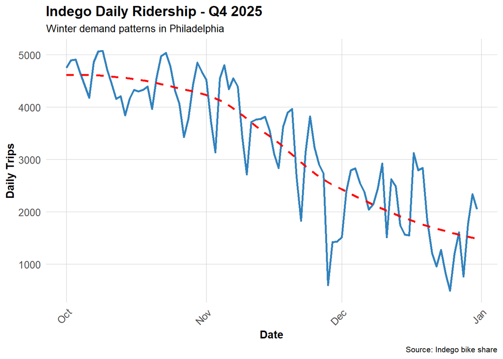

```r
# Daily trip counts
daily_trips <- indego %>%
  group_by(date) %>%
  summarize(trips = n())

ggplot(daily_trips, aes(x = date, y = trips)) +
  geom_line(color = "#3182bd", linewidth = 1) +
  geom_smooth(se = FALSE, color = "red", linetype = "dashed") +
  labs(
    title = "Indego Daily Ridership - Q4 2025",
    subtitle = "Winter demand patterns in Philadelphia",
    x = "Date",
    y = "Daily Trips",
    caption = "Source: Indego bike share"
  ) +
  plotTheme
```

### Interpretation

Daily ridership in Q4 shows a general decline over time, consistent with the transition from fall into winter. Compared to warmer months, demand appears lower and more variable, likely reflecting the influence of colder temperatures and weather conditions on biking behavior.

This seasonal pattern suggests that predicting demand in Q4 may be more challenging than in Q1 or summer quarters, as weather-driven fluctuations introduce additional uncertainty.

## Hourly Patterns

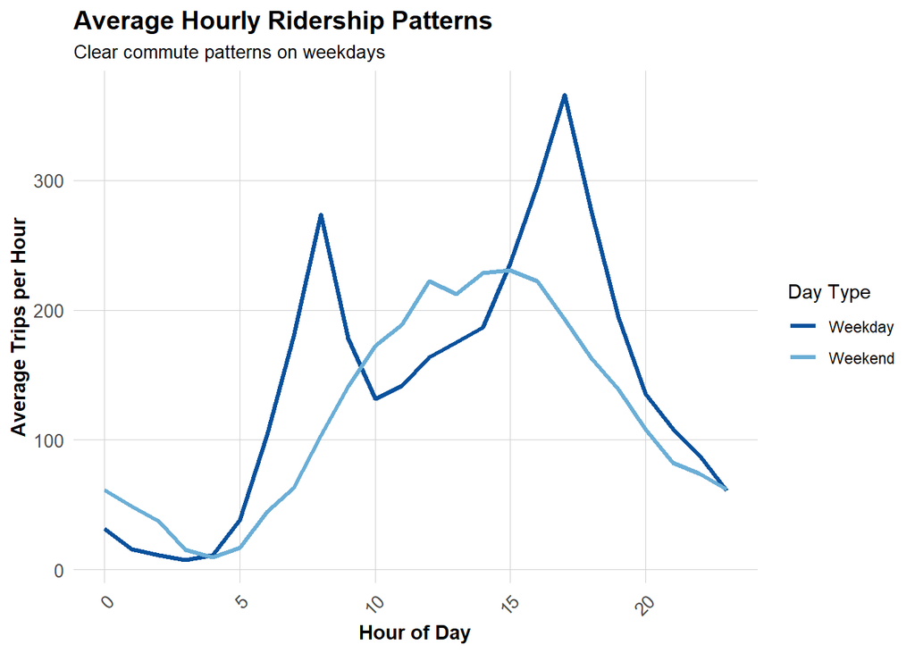

```r
# Average trips by hour and day type
hourly_patterns <- indego %>%
  group_by(hour, weekend) %>%
  summarize(avg_trips = n() / n_distinct(date)) %>%
  mutate(day_type = ifelse(weekend == 1, "Weekend", "Weekday"))

ggplot(hourly_patterns, aes(x = hour, y = avg_trips, color = day_type)) +
  geom_line(linewidth = 1.2) +
  scale_color_manual(values = c("Weekday" = "#08519c", "Weekend" = "#6baed6")) +
  labs(
    title = "Average Hourly Ridership Patterns",
    subtitle = "Clear commute patterns on weekdays",
    x = "Hour of Day",
    y = "Average Trips per Hour",
    color = "Day Type"
  ) +
  plotTheme
```

### Interpretation

Clear temporal patterns emerge in hourly ridership. Weekdays exhibit strong bimodal peaks during morning and evening commute hours, while weekends show a flatter distribution with higher activity in mid-day periods.

These patterns indicate that bike usage is strongly tied to commuting behavior during weekdays, while weekend usage is more recreational. This reinforces the importance of including time-of-day and day-of-week features in predictive models.

## Top Stations

```r
# Most popular origin stations
top_stations <- indego %>%
  count(start_station, start_lat, start_lon, name = "trips") %>%
  arrange(desc(trips)) %>%
  head(20)

kable(top_stations,
      caption = "Top 20 Indego Stations by Trip Origins",
      format.args = list(big.mark = ",")) %>%
  kable_styling(bootstrap_options = c("striped", "hover"))
```

Top 20 Indego Stations by Trip Origins

| start_station | start_lat | start_lon | trips |
| --- | --- | --- | --- |
| 3,010 | 39.94711 | -75.16618 | 5,943 |
| 3,032 | 39.94527 | -75.17971 | 4,471 |
| 3,359 | 39.94888 | -75.16978 | 3,923 |
| 3,244 | 39.93865 | -75.16674 | 3,492 |
| 3,295 | 39.95028 | -75.16027 | 3,411 |
| 3,020 | 39.94855 | -75.19007 | 3,369 |
| 3,208 | 39.95048 | -75.19324 | 3,343 |
| 3,066 | 39.94561 | -75.17348 | 3,342 |
| 3,054 | 39.96250 | -75.17420 | 3,297 |
| 3,101 | 39.94295 | -75.15955 | 3,214 |
| 3,022 | 39.95472 | -75.18323 | 3,152 |
| 3,028 | 39.94061 | -75.14958 | 3,101 |
| 3,362 | 39.94816 | -75.16226 | 3,072 |
| 3,063 | 39.94633 | -75.16980 | 2,972 |
| 3,185 | 39.95169 | -75.15888 | 2,952 |
| 3,059 | 39.96244 | -75.16121 | 2,926 |
| 3,012 | 39.94218 | -75.17747 | 2,907 |
| 3,061 | 39.95425 | -75.17761 | 2,847 |
| 3,161 | 39.95486 | -75.18091 | 2,837 |
| 3,256 | 39.95269 | -75.17779 | 2,816 |

# PUTTING DATA IN CONTEXT

## Loading Philadelphia Census Data

We get census tract data to add demographic context to our stations.

```r
# Get Philadelphia census tracts
philly_census <- get_acs(
  geography = "tract",
  variables = c(
    "B01003_001",  # Total population
    "B19013_001",  # Median household income
    "B08301_001",  # Total commuters
    "B08301_010",  # Commute by transit
    "B02001_002",  # White alone
    "B25077_001"   # Median home value
  ),
  state = "PA",
  county = "Philadelphia",
  year = 2022,
  progress_bar = FALSE,
  geometry = TRUE,
  output = "wide"
) %>%
  rename(
    Total_Pop = B01003_001E,
    Med_Inc = B19013_001E,
    Total_Commuters = B08301_001E,
    Transit_Commuters = B08301_010E,
    White_Pop = B02001_002E,
    Med_Home_Value = B25077_001E
  ) %>%
  mutate(
    Percent_Taking_Transit = (Transit_Commuters / Total_Commuters) * 100,
    Percent_White = (White_Pop / Total_Pop) * 100
  ) %>%
  st_transform(crs = 4326)  #transforming to WGS84 for lat/lon matching, currently in NAD83
```

## Map Philadelphia Context

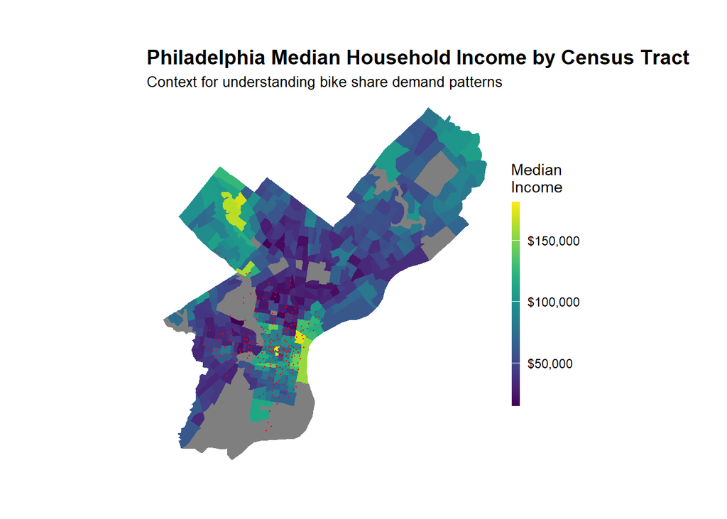

```r
# Map median income
ggplot() +
  geom_sf(data = philly_census, aes(fill = Med_Inc), color = NA) +
  scale_fill_viridis(
    option = "viridis",
    name = "Median\nIncome",
    labels = scales::dollar
  ) +
  labs(
    title = "Philadelphia Median Household Income by Census Tract",
    subtitle = "Context for understanding bike share demand patterns"
  ) +
  # Stations
  geom_point(
    data = indego,
    aes(x = start_lon, y = start_lat),
    color = "red", size = 0.25, alpha = 0.6
  ) +
  mapTheme
```

## Joining Census Data to Stations

We spatially join census characteristics to each bike station.

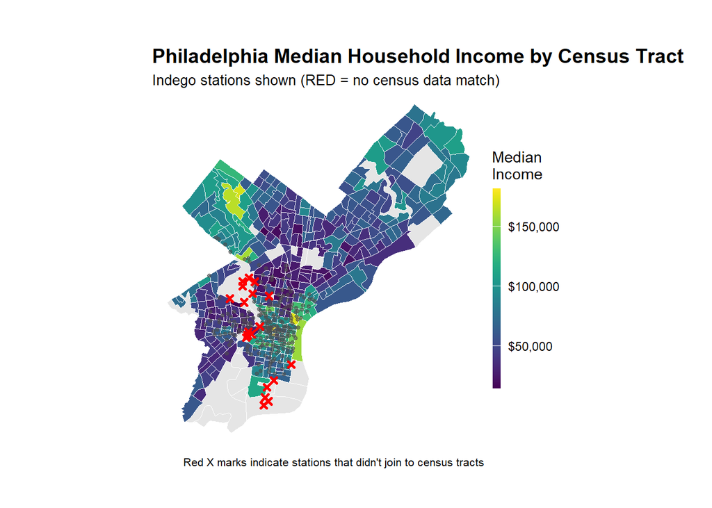

```r
# Create sf object for stations
stations_sf <- indego %>%
  distinct(start_station, start_lat, start_lon) %>%
  filter(!is.na(start_lat), !is.na(start_lon)) %>%
  st_as_sf(coords = c("start_lon", "start_lat"), crs = 4326)

# Spatial join to get census tract for each station
stations_census <- st_join(stations_sf, philly_census, left = TRUE) %>%
  st_drop_geometry()

# Look at the result - investigate whether all of the stations joined to census data -- according to the map above there are stations in non-residential tracts.

stations_for_map <- indego %>%
  distinct(start_station, start_lat, start_lon) %>%
  filter(!is.na(start_lat), !is.na(start_lon)) %>%
  left_join(
    stations_census %>% select(start_station, Med_Inc),
    by = "start_station"
  ) %>%
  mutate(has_census = !is.na(Med_Inc))

# Add back to trip data
indego_census <- indego %>%
  left_join(
    stations_census %>%
      select(start_station, Med_Inc, Percent_Taking_Transit,
             Percent_White, Total_Pop),
    by = "start_station"
  )


# Prepare data for visualization
stations_for_map <- indego %>%
  distinct(start_station, start_lat, start_lon) %>%
  filter(!is.na(start_lat), !is.na(start_lon)) %>%
  left_join(
    stations_census %>% select(start_station, Med_Inc),
    by = "start_station"
  ) %>%
  mutate(has_census = !is.na(Med_Inc))

# Create the map showing problem stations
ggplot() +
  geom_sf(data = philly_census, aes(fill = Med_Inc), color = "white", size = 0.1) +
  scale_fill_viridis(
    option = "viridis",
    name = "Median\nIncome",
    labels = scales::dollar,
    na.value = "grey90"
  ) +
  # Stations with census data (small grey dots)
  geom_point(
    data = stations_for_map %>% filter(has_census),
    aes(x = start_lon, y = start_lat),
    color = "grey30", size = 1, alpha = 0.6
  ) +
  # Stations WITHOUT census data (red X marks the spot)
  geom_point(
    data = stations_for_map %>% filter(!has_census),
    aes(x = start_lon, y = start_lat),
    color = "red", size = 1, shape = 4, stroke = 1.5
  ) +
  labs(
    title = "Philadelphia Median Household Income by Census Tract",
    subtitle = "Indego stations shown (RED = no census data match)",
    caption = "Red X marks indicate stations that didn't join to census tracts"
  ) +
  mapTheme
```

## Dealing with missing data

We need to decide what to do with the non-residential bike share stations. For this example, we are going to remove them – this is not necessarily the right way to do things always, but for the sake of simplicity, we are narrowing our scope to only stations in residential neighborhoods. We might opt to create a separate model for non-residential stations.

```r
# Identify which stations to keep
valid_stations <- stations_census %>%
  filter(!is.na(Med_Inc)) %>%
  pull(start_station)

# Filter trip data to valid stations only
indego_census <- indego %>%
  filter(start_station %in% valid_stations) %>%
  left_join(
    stations_census %>%
      select(start_station, Med_Inc, Percent_Taking_Transit,
             Percent_White, Total_Pop),
    by = "start_station"
  )

indego_census <- indego_census %>%
  mutate(interval60 = floor_date(mdy_hm(start_time), unit = "hour"))
```

## Getting Weather Data

Weather significantly affects bike share demand. We input hourly weather for Philadelphia.

```r
# Get weather from Philadelphia International Airport (KPHL)
# This covers Q4 2024: October 1 - December 31
weather_data <- riem_measures(
  station = "PHL",  # Philadelphia International Airport
  date_start = "2024-10-01",
  date_end = "2024-12-31"
)

# Process weather data
weather_processed <- weather_data %>%
  mutate(
    interval60 = floor_date(valid, unit = "hour"),
    Temperature = tmpf,  # Temperature in Fahrenheit
    Precipitation = ifelse(is.na(p01i), 0, p01i),  # Hourly precip in inches
    Wind_Speed = sknt  # Wind speed in knots
  ) %>%
  select(interval60, Temperature, Precipitation, Wind_Speed) %>%
  distinct(interval60, .keep_all = TRUE)

# Check for missing hours and interpolate if needed
weather_complete <- weather_processed %>%
  complete(interval60 = seq(min(interval60), max(interval60), by = "hour")) %>%
  fill(Temperature, Precipitation, Wind_Speed, .direction = "down")

# Look at the weather
summary(weather_complete %>% select(Temperature, Precipitation, Wind_Speed))
```

```
  Temperature    Precipitation        Wind_Speed
 Min.   :12.00   Min.   :0.000000   Min.   : 0.000
 1st Qu.:40.00   1st Qu.:0.000000   1st Qu.: 4.000
 Median :51.00   Median :0.000000   Median : 7.000
 Mean   :50.87   Mean   :0.001104   Mean   : 7.617
 3rd Qu.:61.00   3rd Qu.:0.000000   3rd Qu.:10.000
 Max.   :83.00   Max.   :0.200000   Max.   :30.000
```

## Visualize Weather Patterns

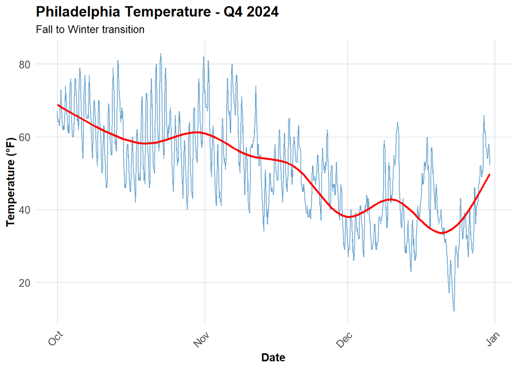

```r
ggplot(weather_complete, aes(x = interval60, y = Temperature)) +
  geom_line(color = "#3182bd", alpha = 0.7) +
  geom_smooth(se = FALSE, color = "red") +
  labs(
    title = "Philadelphia Temperature - Q4 2024",
    subtitle = "Fall to Winter transition",
    x = "Date",
    y = "Temperature (°F)"
  ) +
  plotTheme
```

# CREATE SPACE-TIME PANEL

## Aggregate Trips to Station-Hour Level

```r
# Count trips by station-hour
trips_panel <- indego_census %>%
  group_by(interval60, start_station) %>%
  summarize(Trip_Count = n(), .groups = "drop") %>%
  ungroup()

# How many station-hour observations?
nrow(trips_panel)
```

```
[1] 150972
```

```r
# How many unique stations?
length(unique(trips_panel$start_station))
```

```
[1] 237
```

```r
# How many unique hours?
length(unique(trips_panel$interval60))
```

```
[1] 2208
```

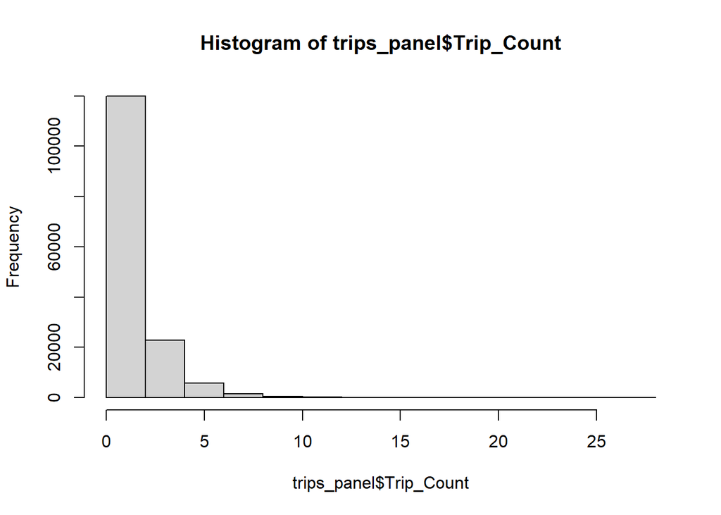

```r
hist(trips_panel$Trip_Count)
```

## Create Complete Panel Structure

Not every station has trips every hour. We need a **complete panel** where every station-hour combination exists (even if Trip_Count = 0).

```r
# Calculate expected panel size
n_stations <- length(unique(trips_panel$start_station))
n_hours <- length(unique(trips_panel$interval60))
expected_rows <- n_stations * n_hours

cat("Expected panel rows:", format(expected_rows, big.mark = ","), "\n")
```

```
Expected panel rows: 523,296
```

```r
cat("Current rows:", format(nrow(trips_panel), big.mark = ","), "\n")
```

```
Current rows: 150,972
```

```r
cat("Missing rows:", format(expected_rows - nrow(trips_panel), big.mark = ","), "\n")
```

```
Missing rows: 372,324
```

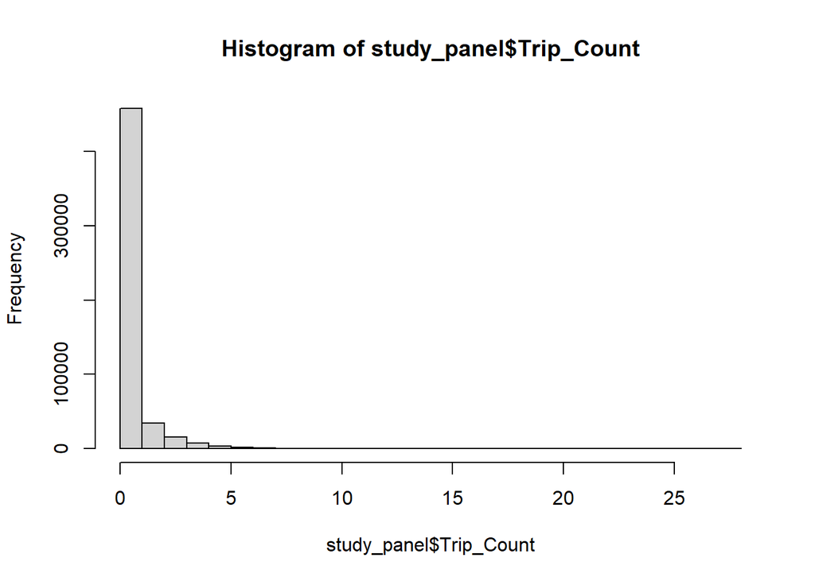

```r
# Create complete panel
study_panel <- expand_grid(
  interval60 = unique(trips_panel$interval60),
  start_station = unique(trips_panel$start_station)
) %>%
  # Join trip counts
  left_join(trips_panel %>%
              select(interval60, start_station, Trip_Count),
            by = c("interval60", "start_station")) %>%
  # Replace NA trip counts with 0
  mutate(Trip_Count = replace_na(Trip_Count, 0))


hist(study_panel$Trip_Count)
```

```r
# Fill in station attributes (they're the same for all hours)
station_attributes <- indego_census %>%
  group_by(start_station) %>%
  summarize(
    start_lat = first(start_lat),
    start_lon = first(start_lon),
    Med_Inc = first(Med_Inc),
    Percent_Taking_Transit = first(Percent_Taking_Transit),
    Percent_White = first(Percent_White),
    Total_Pop = first(Total_Pop),
    .groups = "drop"
  )

glimpse(station_attributes)
```

```
Rows: 237
Columns: 7
$ start_station          <dbl> 3000, 3005, 3006, 3007, 3008, 3009, 3010, 3012,…
$ start_lat              <dbl> 39.91591, 39.94733, 39.95220, 39.94517, 39.9808…
$ start_lon              <dbl> -75.18370, -75.14403, -75.20311, -75.15993, -75…
$ Med_Inc                <dbl> 90221, 144922, 21064, 58557, 22244, 37674, 8858…
$ Percent_Taking_Transit <dbl> 19.295635, 11.742827, 9.418565, 11.401515, 27.4…
$ Percent_White          <dbl> 88.23682, 86.29640, 46.88109, 62.85341, 39.6522…
$ Total_Pop              <dbl> 3851, 3583, 6156, 4598, 5349, 7375, 3134, 3643,…
```

```r
study_panel <- study_panel %>%
  left_join(station_attributes, by = "start_station")


# Verify we have complete panel
cat("Complete panel rows:", format(nrow(study_panel), big.mark = ","), "\n")
```

```
Complete panel rows: 523,296
```

## Add Time Features

```r
study_panel <- study_panel %>%
  mutate(
    # Create week index relative to dataset (NOT calendar week)
    week = as.numeric(difftime(interval60, min(interval60), units = "weeks")) + 1,

    # Standard time variables
    month = month(interval60, label = TRUE),
    dotw = wday(interval60, label = TRUE),
    hour = hour(interval60),
    date = as.Date(interval60),

    # Weekend indicator
    weekend = ifelse(dotw %in% c("Sat", "Sun"), 1, 0),

    # Rush hour indicator
    rush_hour = ifelse(hour %in% c(7, 8, 9, 16, 17, 18), 1, 0),

    # imple weekday/weekend categorical variable
    dotw_simple = ifelse(dotw %in% c("Sat", "Sun"), "Weekend", "Weekday")
  )

glimpse(study_panel)
```

```
Rows: 523,296
Columns: 17
$ interval60             <dttm> 2024-10-01, 2024-10-01, 2024-10-01, 2024-10-01…
$ start_station          <dbl> 3007, 3008, 3010, 3025, 3030, 3033, 3041, 3075,…
$ Trip_Count             <int> 3, 1, 2, 3, 1, 1, 1, 1, 1, 1, 1, 1, 1, 1, 3, 1,…
$ start_lat              <dbl> 39.94517, 39.98081, 39.94711, 39.93724, 39.9393…
$ start_lon              <dbl> -75.15993, -75.15067, -75.16618, -75.16120, -75…
$ Med_Inc                <dbl> 58557, 22244, 88583, 98015, 114063, 69267, 1277…
$ Percent_Taking_Transit <dbl> 11.401515, 27.430556, 20.165209, 16.707106, 5.4…
$ Percent_White          <dbl> 62.85341, 39.65227, 82.86535, 77.82027, 75.5757…
$ Total_Pop              <dbl> 4598, 5349, 3134, 4707, 3300, 3057, 2273, 3500,…
$ week                   <dbl> 1, 1, 1, 1, 1, 1, 1, 1, 1, 1, 1, 1, 1, 1, 1, 1,…
$ month                  <ord> Oct, Oct, Oct, Oct, Oct, Oct, Oct, Oct, Oct, Oc…
$ dotw                   <ord> Tue, Tue, Tue, Tue, Tue, Tue, Tue, Tue, Tue, Tu…
$ hour                   <int> 0, 0, 0, 0, 0, 0, 0, 0, 0, 0, 0, 0, 0, 0, 0, 0,…
$ date                   <date> 2024-10-01, 2024-10-01, 2024-10-01, 2024-10-01…
$ weekend                <dbl> 0, 0, 0, 0, 0, 0, 0, 0, 0, 0, 0, 0, 0, 0, 0, 0,…
$ rush_hour              <dbl> 0, 0, 0, 0, 0, 0, 0, 0, 0, 0, 0, 0, 0, 0, 0, 0,…
$ dotw_simple            <chr> "Weekday", "Weekday", "Weekday", "Weekday", "We…
```

## Join Weather Data

```r
study_panel <- study_panel %>%
  left_join(weather_complete, by = "interval60")

glimpse(study_panel)
```

```
Rows: 523,296
Columns: 20
$ interval60             <dttm> 2024-10-01, 2024-10-01, 2024-10-01, 2024-10-01…
$ start_station          <dbl> 3007, 3008, 3010, 3025, 3030, 3033, 3041, 3075,…
$ Trip_Count             <int> 3, 1, 2, 3, 1, 1, 1, 1, 1, 1, 1, 1, 1, 1, 3, 1,…
$ start_lat              <dbl> 39.94517, 39.98081, 39.94711, 39.93724, 39.9393…
$ start_lon              <dbl> -75.15993, -75.15067, -75.16618, -75.16120, -75…
$ Med_Inc                <dbl> 58557, 22244, 88583, 98015, 114063, 69267, 1277…
$ Percent_Taking_Transit <dbl> 11.401515, 27.430556, 20.165209, 16.707106, 5.4…
$ Percent_White          <dbl> 62.85341, 39.65227, 82.86535, 77.82027, 75.5757…
$ Total_Pop              <dbl> 4598, 5349, 3134, 4707, 3300, 3057, 2273, 3500,…
$ week                   <dbl> 1, 1, 1, 1, 1, 1, 1, 1, 1, 1, 1, 1, 1, 1, 1, 1,…
$ month                  <ord> Oct, Oct, Oct, Oct, Oct, Oct, Oct, Oct, Oct, Oc…
$ dotw                   <ord> Tue, Tue, Tue, Tue, Tue, Tue, Tue, Tue, Tue, Tu…
$ hour                   <int> 0, 0, 0, 0, 0, 0, 0, 0, 0, 0, 0, 0, 0, 0, 0, 0,…
$ date                   <date> 2024-10-01, 2024-10-01, 2024-10-01, 2024-10-01…
$ weekend                <dbl> 0, 0, 0, 0, 0, 0, 0, 0, 0, 0, 0, 0, 0, 0, 0, 0,…
$ rush_hour              <dbl> 0, 0, 0, 0, 0, 0, 0, 0, 0, 0, 0, 0, 0, 0, 0, 0,…
$ dotw_simple            <chr> "Weekday", "Weekday", "Weekday", "Weekday", "We…
$ Temperature            <dbl> 67, 67, 67, 67, 67, 67, 67, 67, 67, 67, 67, 67,…
$ Precipitation          <dbl> 0, 0, 0, 0, 0, 0, 0, 0, 0, 0, 0, 0, 0, 0, 0, 0,…
$ Wind_Speed             <dbl> 10, 10, 10, 10, 10, 10, 10, 10, 10, 10, 10, 10,…
```

```r
# Check for missing values
summary(study_panel %>% select(Trip_Count, Temperature, Precipitation))
```

```
   Trip_Count       Temperature    Precipitation
 Min.   : 0.0000   Min.   :12.00   Min.   :0.0000
 1st Qu.: 0.0000   1st Qu.:40.00   1st Qu.:0.0000
 Median : 0.0000   Median :51.00   Median :0.0000
 Mean   : 0.5383   Mean   :50.87   Mean   :0.0011
 3rd Qu.: 1.0000   3rd Qu.:61.00   3rd Qu.:0.0000
 Max.   :28.0000   Max.   :83.00   Max.   :0.2000
                   NA's   :5688    NA's   :5688
```

# CREATING TEMPORAL LAG VARIABLES

The key innovation for space-time prediction: **past demand predicts future demand**.

## Why Temporal Lags?

If there were 15 bike trips from Station A at 8:00 AM, there will probably be ~15 trips at 9:00 AM. We use this temporal persistence to improve predictions.

```r
# Sort by station and time
study_panel <- study_panel %>%
  arrange(start_station, interval60)

# Creating lag variables WITHIN each station
study_panel <- study_panel %>%
  group_by(start_station) %>%
  mutate(
    lag1Hour = lag(Trip_Count, 1),
    lag2Hours = lag(Trip_Count, 2),
    lag3Hours = lag(Trip_Count, 3),
    lag12Hours = lag(Trip_Count, 12),
    lag1day = lag(Trip_Count, 24)
  ) %>%
  ungroup()

# Remove rows with NA lags (first 24 hours for each station)
study_panel_complete <- study_panel %>%
  filter(!is.na(lag1day))

# ================================
# NEW FEATURE ENGINEERING
# ================================

study_panel_complete <- study_panel_complete %>%
  arrange(start_station, interval60) %>%
  group_by(start_station) %>%
  mutate(

    # 1. Good weather indicator
    good_weather = ifelse(
      Temperature >= 50 & Temperature <= 75 & Precipitation == 0,
      1, 0
    ),

    # 2. Same hour last week (strong predictor)
    lag1week = lag(Trip_Count, 24 * 7),

    # 3. Rolling 24-hour average demand
    rolling_avg_24 = zoo::rollmean(
      Trip_Count,
      k = 24,
      fill = NA,
      align = "right"
    )

  ) %>%
  ungroup()

study_panel_complete <- study_panel_complete %>%
  filter(!is.na(lag1week), !is.na(rolling_avg_24))

cat("Rows after removing NA lags:", format(nrow(study_panel_complete), big.mark = ","), "\n")
```

```
Rows after removing NA lags: 477,792
```

## Visualize Lag Correlations

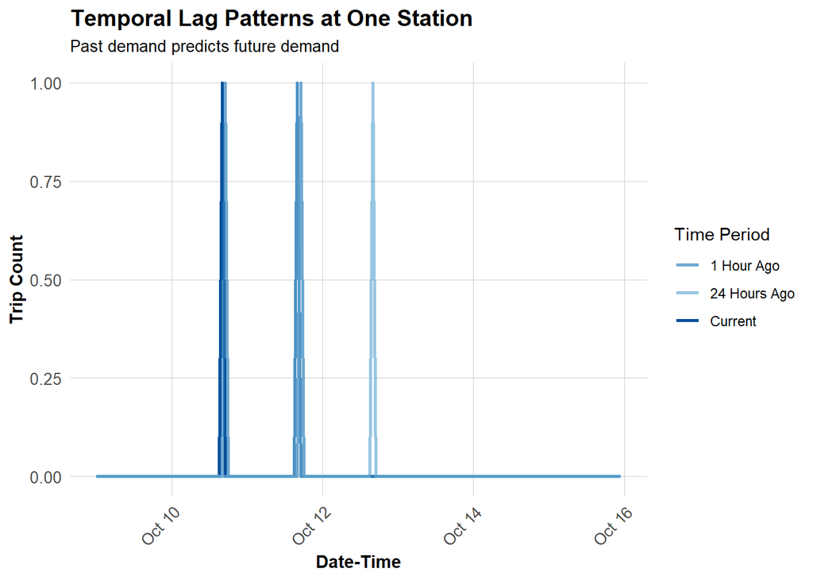

```r
# Sampling one station to visualize
example_station <- study_panel_complete %>%
  filter(start_station == first(start_station)) %>%
  head(168)  # One week

# Plot actual vs lagged demand
ggplot(example_station, aes(x = interval60)) +
  geom_line(aes(y = Trip_Count, color = "Current"), linewidth = 1) +
  geom_line(aes(y = lag1Hour, color = "1 Hour Ago"), linewidth = 1, alpha = 0.7) +
  geom_line(aes(y = lag1day, color = "24 Hours Ago"), linewidth = 1, alpha = 0.7) +
  scale_color_manual(values = c(
    "Current" = "#08519c",
    "1 Hour Ago" = "#3182bd",
    "24 Hours Ago" = "#6baed6"
  )) +
  labs(
    title = "Temporal Lag Patterns at One Station",
    subtitle = "Past demand predicts future demand",
    x = "Date-Time",
    y = "Trip Count",
    color = "Time Period"
  ) +
  plotTheme
```

### Interpretation

This justifies the inclusion of temporal lag variables in the model, as past demand provides substantial predictive power. It also suggests that bike usage follows stable short-term and daily cycles, which can be leveraged for forecasting.

# TEMPORAL TRAIN/TEST SPLIT

**CRITICAL:** We must train on PAST data and test on FUTURE data!

```r
# Split by week
# Q1 has weeks 1-13 (Oct-Dec)
# Train on weeks 1-9 (Oct 1 - early December)
# Test on weeks 10-13 (rest of Dec)

# Which stations have trips in BOTH early and late periods?
early_stations <- study_panel_complete %>%
  filter(week < 10) %>%
  filter(Trip_Count > 0) %>%
  distinct(start_station) %>%
  pull(start_station)

late_stations <- study_panel_complete %>%
  filter(week >= 10) %>%
  filter(Trip_Count > 0) %>%
  distinct(start_station) %>%
  pull(start_station)

# Keep only stations that appear in BOTH periods
common_stations <- intersect(early_stations, late_stations)


# Filter panel to only common stations
study_panel_complete <- study_panel_complete %>%
  filter(start_station %in% common_stations)

# NOW create train/test split
train <- study_panel_complete %>%
  filter(week < 10)

test <- study_panel_complete %>%
  filter(week >= 10)

cat("Training observations:", format(nrow(train), big.mark = ","), "\n")
```

```
Training observations: 300,960
```

```r
cat("Testing observations:", format(nrow(test), big.mark = ","), "\n")
```

```
Testing observations: 158,688
```

```r
cat("Training date range:", min(train$date), "to", max(train$date), "\n")
```

```
Training date range: 20005 to 20059
```

```r
cat("Testing date range:", min(test$date), "to", max(test$date), "\n")
```

```
Testing date range: 20060 to 20088
```

#BUILD PREDICTIVE MODELS

## Model 1: Baseline (Time + Weather)

```r
# Create day of week factor with treatment (dummy) coding
train <- train %>%
  mutate(dotw_simple = factor(dotw, levels = c("Mon", "Tue", "Wed", "Thu", "Fri", "Sat", "Sun")))

# Set contrasts to treatment coding (dummy variables)
contrasts(train$dotw_simple) <- contr.treatment(7)

# Now run the model
model1 <- lm(
  Trip_Count ~ as.factor(hour) + dotw_simple + Temperature + Precipitation,
  data = train
)

summary(model1)
```

```
Call:
lm(formula = Trip_Count ~ as.factor(hour) + dotw_simple + Temperature +
    Precipitation, data = train)

Residuals:
    Min      1Q  Median      3Q     Max
-1.7073 -0.6853 -0.2041  0.1799 27.2578

Coefficients:
                    Estimate Std. Error t value             Pr(>|t|)
(Intercept)       -0.4824802  0.0165868 -29.088 < 0.0000000000000002 ***
as.factor(hour)1  -0.0610223  0.0146092  -4.177    0.000029549943132 ***
as.factor(hour)2  -0.0785021  0.0146156  -5.371    0.000000078308753 ***
as.factor(hour)3  -0.1032316  0.0146278  -7.057    0.000000000001702 ***
as.factor(hour)4  -0.0909844  0.0146371  -6.216    0.000000000510636 ***
as.factor(hour)5   0.0342745  0.0146631   2.337             0.019415 *
as.factor(hour)6   0.3049016  0.0146719  20.781 < 0.0000000000000002 ***
as.factor(hour)7   0.5780058  0.0146967  39.329 < 0.0000000000000002 ***
as.factor(hour)8   0.9785750  0.0146910  66.611 < 0.0000000000000002 ***
as.factor(hour)9   0.7018894  0.0147019  47.741 < 0.0000000000000002 ***
as.factor(hour)10  0.5908061  0.0147347  40.096 < 0.0000000000000002 ***
as.factor(hour)11  0.6419711  0.0147062  43.653 < 0.0000000000000002 ***
as.factor(hour)12  0.7200450  0.0146515  49.145 < 0.0000000000000002 ***
as.factor(hour)13  0.6990560  0.0146186  47.819 < 0.0000000000000002 ***
as.factor(hour)14  0.7256878  0.0146070  49.681 < 0.0000000000000002 ***
as.factor(hour)15  0.8261898  0.0146208  56.508 < 0.0000000000000002 ***
as.factor(hour)16  0.9569440  0.0146479  65.330 < 0.0000000000000002 ***
as.factor(hour)17  1.1470203  0.0146766  78.153 < 0.0000000000000002 ***
as.factor(hour)18  0.8422080  0.0146930  57.321 < 0.0000000000000002 ***
as.factor(hour)19  0.5302853  0.0146926  36.092 < 0.0000000000000002 ***
as.factor(hour)20  0.3369866  0.0146832  22.951 < 0.0000000000000002 ***
as.factor(hour)21  0.2361630  0.0146432  16.128 < 0.0000000000000002 ***
as.factor(hour)22  0.1714785  0.0146172  11.731 < 0.0000000000000002 ***
as.factor(hour)23  0.0743660  0.0146082   5.091    0.000000356940835 ***
dotw_simple2       0.0305117  0.0081209   3.757             0.000172 ***
dotw_simple3       0.0490926  0.0078518   6.252    0.000000000404814 ***
dotw_simple4      -0.0136682  0.0078683  -1.737             0.082367 .
dotw_simple5      -0.0197313  0.0078178  -2.524             0.011607 *
dotw_simple6      -0.0318649  0.0078217  -4.074    0.000046247663766 ***
dotw_simple7      -0.0573468  0.0078395  -7.315    0.000000000000258 ***
Temperature        0.0123443  0.0002179  56.658 < 0.0000000000000002 ***
Precipitation     -5.0785986  0.3427515 -14.817 < 0.0000000000000002 ***
---
Signif. codes:  0 '***' 0.001 '**' 0.01 '*' 0.05 '.' 0.1 ' ' 1

Residual standard error: 1.157 on 300928 degrees of freedom
Multiple R-squared:  0.1156,    Adjusted R-squared:  0.1155
F-statistic:  1269 on 31 and 300928 DF,  p-value: < 0.00000000000000022
```

## Model 2: Adding Temporal Lags

```r
model2 <- lm(
  Trip_Count ~ as.factor(hour) + dotw_simple + Temperature + Precipitation +
    lag1Hour + lag3Hours + lag1day,
  data = train
)

summary(model2)
```

```
Call:
lm(formula = Trip_Count ~ as.factor(hour) + dotw_simple + Temperature +
    Precipitation + lag1Hour + lag3Hours + lag1day, data = train)

Residuals:
     Min       1Q   Median       3Q      Max
-12.6910  -0.4733  -0.1239   0.1100  25.5764

Coefficients:
                    Estimate Std. Error t value             Pr(>|t|)
(Intercept)       -0.2030498  0.0145612 -13.945 < 0.0000000000000002 ***
as.factor(hour)1  -0.0164436  0.0127992  -1.285             0.198887
as.factor(hour)2  -0.0016890  0.0128079  -0.132             0.895083
as.factor(hour)3  -0.0077890  0.0128215  -0.607             0.543524
as.factor(hour)4   0.0165741  0.0128337   1.291             0.196550
as.factor(hour)5   0.1023561  0.0128583   7.960  0.00000000000000172 ***
as.factor(hour)6   0.2732035  0.0128829  21.207 < 0.0000000000000002 ***
as.factor(hour)7   0.3985365  0.0129351  30.810 < 0.0000000000000002 ***
as.factor(hour)8   0.6099061  0.0129986  46.921 < 0.0000000000000002 ***
as.factor(hour)9   0.2812484  0.0129873  21.656 < 0.0000000000000002 ***
as.factor(hour)10  0.2400902  0.0129620  18.523 < 0.0000000000000002 ***
as.factor(hour)11  0.2649498  0.0129554  20.451 < 0.0000000000000002 ***
as.factor(hour)12  0.3492480  0.0128960  27.082 < 0.0000000000000002 ***
as.factor(hour)13  0.3318155  0.0128694  25.783 < 0.0000000000000002 ***
as.factor(hour)14  0.3533853  0.0128606  27.478 < 0.0000000000000002 ***
as.factor(hour)15  0.4096064  0.0128878  31.783 < 0.0000000000000002 ***
as.factor(hour)16  0.4782023  0.0129404  36.954 < 0.0000000000000002 ***
as.factor(hour)17  0.5717248  0.0130137  43.933 < 0.0000000000000002 ***
as.factor(hour)18  0.2938427  0.0130064  22.592 < 0.0000000000000002 ***
as.factor(hour)19  0.1243790  0.0129486   9.606 < 0.0000000000000002 ***
as.factor(hour)20  0.0366186  0.0129358   2.831             0.004643 **
as.factor(hour)21  0.0384702  0.0128610   2.991             0.002779 **
as.factor(hour)22  0.0475883  0.0128148   3.714             0.000204 ***
as.factor(hour)23  0.0171921  0.0127989   1.343             0.179195
dotw_simple2      -0.0039408  0.0071154  -0.554             0.579688
dotw_simple3      -0.0076977  0.0068820  -1.119             0.263342
dotw_simple4      -0.0516523  0.0068980  -7.488  0.00000000000007012 ***
dotw_simple5      -0.0394101  0.0068507  -5.753  0.00000000879211183 ***
dotw_simple6      -0.0437517  0.0068538  -6.384  0.00000000017331027 ***
dotw_simple7      -0.0630828  0.0068699  -9.182 < 0.0000000000000002 ***
Temperature        0.0044680  0.0001928  23.170 < 0.0000000000000002 ***
Precipitation     -2.6088516  0.3004599  -8.683 < 0.0000000000000002 ***
lag1Hour           0.2470954  0.0017546 140.825 < 0.0000000000000002 ***
lag3Hours          0.1113215  0.0017017  65.418 < 0.0000000000000002 ***
lag1day            0.2788452  0.0017023 163.806 < 0.0000000000000002 ***
---
Signif. codes:  0 '***' 0.001 '**' 0.01 '*' 0.05 '.' 0.1 ' ' 1

Residual standard error: 1.013 on 300925 degrees of freedom
Multiple R-squared:  0.3213,    Adjusted R-squared:  0.3212
F-statistic:  4190 on 34 and 300925 DF,  p-value: < 0.00000000000000022
```

## Model 3: Add Demographics

```r
model3 <- lm(
  Trip_Count ~ as.factor(hour) + dotw_simple + Temperature + Precipitation +
    lag1Hour + lag3Hours + lag1day +
    Med_Inc + Percent_Taking_Transit + Percent_White,
  data = train
)

summary(model3)
```

```
Call:
lm(formula = Trip_Count ~ as.factor(hour) + dotw_simple + Temperature +
    Precipitation + lag1Hour + lag3Hours + lag1day + Med_Inc +
    Percent_Taking_Transit + Percent_White, data = train)

Residuals:
     Min       1Q   Median       3Q      Max
-12.2755  -0.4728  -0.1332   0.1649  25.5343

Coefficients:
                             Estimate     Std. Error t value
(Intercept)            -0.33809005086  0.01636243036 -20.663
as.factor(hour)1       -0.01827821332  0.01275888781  -1.433
as.factor(hour)2       -0.00508736111  0.01276766542  -0.398
as.factor(hour)3       -0.01215907997  0.01278146726  -0.951
as.factor(hour)4        0.01145204870  0.01279375275   0.895
as.factor(hour)5        0.09840964435  0.01281805147   7.677
as.factor(hour)6        0.27214082647  0.01284228913  21.191
as.factor(hour)7        0.40217378898  0.01289454367  31.189
as.factor(hour)8        0.61996188253  0.01295958834  47.838
as.factor(hour)9        0.29446184511  0.01294981003  22.739
as.factor(hour)10       0.25262799915  0.01292430156  19.547
as.factor(hour)11       0.28045673552  0.01291937159  21.708
as.factor(hour)12       0.36280529792  0.01285908200  28.214
as.factor(hour)13       0.34439205330  0.01283204317  26.838
as.factor(hour)14       0.36624754220  0.01282337487  28.561
as.factor(hour)15       0.42426793306  0.01285147421  33.013
as.factor(hour)16       0.49467789497  0.01290509518  38.332
as.factor(hour)17       0.59146442039  0.01298046021  45.566
as.factor(hour)18       0.31342305498  0.01297303171  24.160
as.factor(hour)19       0.14040771200  0.01291298501  10.873
as.factor(hour)20       0.05052132686  0.01289885308   3.917
as.factor(hour)21       0.04770787906  0.01282219440   3.721
as.factor(hour)22       0.05299818070  0.01277494457   4.149
as.factor(hour)23       0.01952618954  0.01275864828   1.530
dotw_simple2           -0.00265203150  0.00709297874  -0.374
dotw_simple3           -0.00561907711  0.00686043192  -0.819
dotw_simple4           -0.05049533636  0.00687629643  -7.343
dotw_simple5           -0.03883471694  0.00682912243  -5.687
dotw_simple6           -0.04346970015  0.00683221730  -6.362
```

[output cut: 39 more lines]

```
dotw_simple7           < 0.0000000000000002 ***
Temperature            < 0.0000000000000002 ***
Precipitation          < 0.0000000000000002 ***
lag1Hour               < 0.0000000000000002 ***
lag3Hours              < 0.0000000000000002 ***
lag1day                < 0.0000000000000002 ***
Med_Inc                  0.0000000131043934 ***
Percent_Taking_Transit < 0.0000000000000002 ***
Percent_White          < 0.0000000000000002 ***
---
Signif. codes:  0 '***' 0.001 '**' 0.01 '*' 0.05 '.' 0.1 ' ' 1

Residual standard error: 1.01 on 300922 degrees of freedom
Multiple R-squared:  0.3256,    Adjusted R-squared:  0.3255
F-statistic:  3926 on 37 and 300922 DF,  p-value: < 0.00000000000000022
```

## Model 4: Add Station Fixed Effects

```r
model4 <- lm(
  Trip_Count ~ as.factor(hour) + dotw_simple + Temperature + Precipitation +
    lag1Hour + lag3Hours + lag1day +
    Med_Inc + Percent_Taking_Transit + Percent_White +
    as.factor(start_station),
  data = train
)

# Summary too long with all station dummies, just show key metrics
cat("Model 4 R-squared:", summary(model4)$r.squared, "\n")
```

```
Model 4 R-squared: 0.351306
```

```r
cat("Model 4 Adj R-squared:", summary(model4)$adj.r.squared, "\n")
```

```
Model 4 Adj R-squared: 0.3507429
```

## Model 5: Add Rush Hour Interaction

```r
model5 <- lm(
  Trip_Count ~ as.factor(hour) + dotw_simple + Temperature + Precipitation +
    lag1Hour + lag3Hours + lag1day + rush_hour + as.factor(month) +
    Med_Inc + Percent_Taking_Transit + Percent_White +
    as.factor(start_station) +
    rush_hour * weekend,  # Rush hour effects different on weekends
  data = train
)

cat("Model 5 R-squared:", summary(model5)$r.squared, "\n")
```

```
Model 5 R-squared: 0.355339
```

```r
cat("Model 5 Adj R-squared:", summary(model5)$adj.r.squared, "\n")
```

```
Model 5 Adj R-squared: 0.3547731
```

## Model 6: New Created Model

```r
model6 <- lm(
  Trip_Count ~ as.factor(hour) + dotw_simple + Temperature + Precipitation +
    lag1Hour + lag3Hours + lag1day +
    Med_Inc + Percent_Taking_Transit + Percent_White +
    as.factor(start_station) +
    rush_hour + weekend +
    good_weather + lag1week + rolling_avg_24,
  data = train
)
```

## Poisson Model: Count-based regression

```r
model_pois <- glm(
  Trip_Count ~ as.factor(hour) + as.factor(dotw) + Temperature + Precipitation +
    lag1Hour + lag3Hours + lag1day +
    Med_Inc + Percent_Taking_Transit + Percent_White,
  data = train,
  family = "poisson"
)

# Generate predictions
test <- test %>%
  mutate(
    pred_pois = predict(model_pois, newdata = test, type = "response")
  )

# Calculate MAE
mae_pois <- mean(abs(test$Trip_Count - test$pred_pois), na.rm = TRUE)

mae_pois
```

```
[1] 0.4701858
```

# MODEL EVALUATION

## Calculate Predictions and MAE

```r
# Get predictions on test set

# Create day of week factor with treatment (dummy) coding
test <- test %>%
  mutate(dotw_simple = factor(dotw, levels = c("Mon", "Tue", "Wed", "Thu", "Fri", "Sat", "Sun")))

# Set contrasts to treatment coding (dummy variables)
contrasts(test$dotw_simple) <- contr.treatment(7)

test <- test %>%
  mutate(
    pred1 = predict(model1, newdata = test),
    pred2 = predict(model2, newdata = test),
    pred3 = predict(model3, newdata = test),
    pred4 = predict(model4, newdata = test),
    pred5 = predict(model5, newdata = test),
    pred6 = predict(model6, newdata = test)
  )

# Calculate MAE for each model
mae_results <- data.frame(
  Model = c(
    "1. Time + Weather",
    "2. + Temporal Lags",
    "3. + Demographics",
    "4. + Station FE",
    "5. + Rush Hour Interaction",
    "6. + New Features",
    "7. Poisson Model"
  ),
  MAE = c(
    mean(abs(test$Trip_Count - test$pred1), na.rm = TRUE),
    mean(abs(test$Trip_Count - test$pred2), na.rm = TRUE),
    mean(abs(test$Trip_Count - test$pred3), na.rm = TRUE),
    mean(abs(test$Trip_Count - test$pred4), na.rm = TRUE),
    mean(abs(test$Trip_Count - test$pred5), na.rm = TRUE),
    mean(abs(test$Trip_Count - test$pred6), na.rm = TRUE),
    mean(abs(test$Trip_Count - test$pred_pois), na.rm = TRUE)
  )
)

kable(mae_results,
      digits = 2,
      caption = "Mean Absolute Error by Model (Test Set)",
      col.names = c("Model", "MAE (trips)")) %>%
  kable_styling(bootstrap_options = c("striped", "hover"))
```

Mean Absolute Error by Model (Test Set)

| Model | MAE (trips) |
| --- | --- |
| 1. Time + Weather | 0.55 |
| 2. + Temporal Lags | 0.44 |
| 3. + Demographics | 0.44 |
| 4. + Station FE | 0.47 |
| 5. + Rush Hour Interaction | 0.47 |
| 6. + New Features | 0.42 |
| 7. Poisson Model | 0.47 |

## Visualize Model Comparison

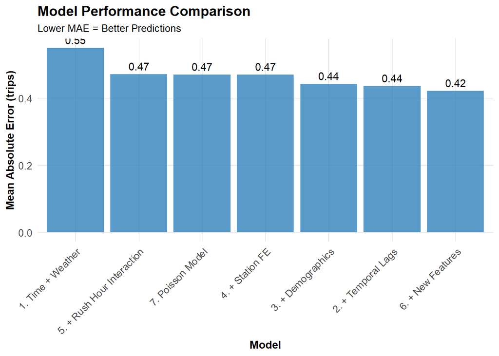

```r
ggplot(mae_results, aes(x = reorder(Model, -MAE), y = MAE)) +
  geom_col(fill = "#3182bd", alpha = 0.8) +
  geom_text(aes(label = round(MAE, 2)), vjust = -0.5) +
  labs(
    title = "Model Performance Comparison",
    subtitle = "Lower MAE = Better Predictions",
    x = "Model",
    y = "Mean Absolute Error (trips)"
  ) +
  plotTheme +
  theme(axis.text.x = element_text(angle = 45, hjust = 1))
```

# SPACE-TIME ERROR ANALYSIS

## Observed vs. Predicted

Let’s use our old best model (Model 2) for error analysis.

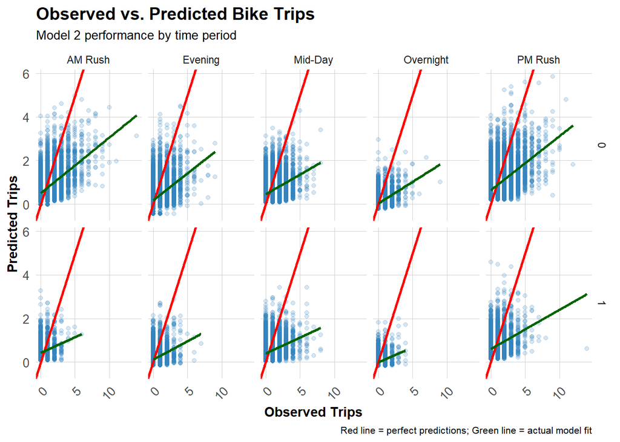

```r
test <- test %>%
  mutate(
    error = Trip_Count - pred2,
    abs_error = abs(error),
    time_of_day = case_when(
      hour < 7 ~ "Overnight",
      hour >= 7 & hour < 10 ~ "AM Rush",
      hour >= 10 & hour < 15 ~ "Mid-Day",
      hour >= 15 & hour <= 18 ~ "PM Rush",
      hour > 18 ~ "Evening"
    )
  )

# Scatter plot by time and day type
ggplot(test, aes(x = Trip_Count, y = pred2)) +
  geom_point(alpha = 0.2, color = "#3182bd") +
  geom_abline(slope = 1, intercept = 0, color = "red", linewidth = 1) +
  geom_smooth(method = "lm", se = FALSE, color = "darkgreen") +
  facet_grid(weekend ~ time_of_day) +
  labs(
    title = "Observed vs. Predicted Bike Trips",
    subtitle = "Model 2 performance by time period",
    x = "Observed Trips",
    y = "Predicted Trips",
    caption = "Red line = perfect predictions; Green line = actual model fit"
  ) +
  plotTheme
```

### Interpretation

The model performs reasonably well overall, with predictions generally tracking observed values. However, there is noticeable dispersion around the ideal prediction line, particularly at higher trip counts.

Errors are more pronounced during peak periods, where demand is both higher and more variable. This suggests that while the model captures general trends, it struggles to fully account for fluctuations during high-demand periods, which are operationally critical for bike rebalancing.

## Spatial Error Patterns

Are prediction errors clustered in certain parts of Philadelphia?

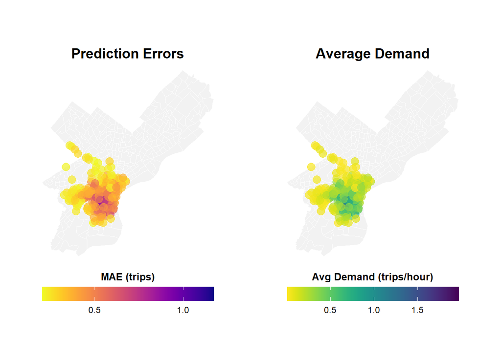

```r
# Calculate MAE by station
station_errors <- test %>%
  group_by(start_station, start_lat, start_lon) %>%
  summarize(
    MAE = mean(abs_error, na.rm = TRUE),
    avg_demand = mean(Trip_Count, na.rm = TRUE),
    .groups = "drop"
  ) %>%
  filter(!is.na(start_lat), !is.na(start_lon))

## Create Two Maps Side-by-Side with Proper Legends (sorry these maps are ugly)

# Calculate station errors
station_errors <- test %>%
  filter(!is.na(pred2)) %>%
  group_by(start_station, start_lat, start_lon) %>%
  summarize(
    MAE = mean(abs(Trip_Count - pred2), na.rm = TRUE),
    avg_demand = mean(Trip_Count, na.rm = TRUE),
    .groups = "drop"
  ) %>%
  filter(!is.na(start_lat), !is.na(start_lon))

# Map 1: Prediction Errors
p1 <- ggplot() +
  geom_sf(data = philly_census, fill = "grey95", color = "white", size = 0.2) +
  geom_point(
    data = station_errors,
    aes(x = start_lon, y = start_lat, color = MAE),
    size = 3.5,
    alpha = 0.7
  ) +
  scale_color_viridis(
    option = "plasma",
    name = "MAE\n(trips)",
    direction = -1,
    breaks = c(0.5, 1.0, 1.5),  # Fewer, cleaner breaks
    labels = c("0.5", "1.0", "1.5")
  ) +
  labs(title = "Prediction Errors",
       subtitle = "Higher in Center City") +
  mapTheme +
  theme(
    legend.position = "right",
    legend.title = element_text(size = 10, face = "bold"),
    legend.text = element_text(size = 9),
    plot.title = element_text(size = 14, face = "bold"),
    plot.subtitle = element_text(size = 10)
  ) +
  guides(color = guide_colorbar(
    barwidth = 1.5,
    barheight = 12,
    title.position = "top",
    title.hjust = 0.5
  ))

# Map 2: Average Demand
p2 <- ggplot() +
  geom_sf(data = philly_census, fill = "grey95", color = "white", size = 0.2) +
  geom_point(
    data = station_errors,
    aes(x = start_lon, y = start_lat, color = avg_demand),
    size = 3.5,
    alpha = 0.7
  ) +
  scale_color_viridis(
    option = "viridis",
    name = "Avg\nDemand",
    direction = -1,
    breaks = c(0.5, 1.0, 1.5, 2.0, 2.5),  # Clear breaks
    labels = c("0.5", "1.0", "1.5", "2.0", "2.5")
  ) +
  labs(title = "Average Demand",
       subtitle = "Trips per station-hour") +
  mapTheme +
  theme(
    legend.position = "right",
    legend.title = element_text(size = 10, face = "bold"),
    legend.text = element_text(size = 9),
    plot.title = element_text(size = 14, face = "bold"),
    plot.subtitle = element_text(size = 10)
  ) +
  guides(color = guide_colorbar(
    barwidth = 1.5,
    barheight = 12,
    title.position = "top",
    title.hjust = 0.5
  ))




# Map 1: Prediction Errors
p1 <- ggplot() +
  geom_sf(data = philly_census, fill = "grey95", color = "white", size = 0.1) +
  geom_point(
    data = station_errors,
    aes(x = start_lon, y = start_lat, color = MAE),
    size = 3.5,
    alpha = 0.7
  ) +
  scale_color_viridis(
    option = "plasma",
    name = "MAE (trips)",
    direction = -1,
    breaks = c(0.5, 1.0, 1.5),
    labels = c("0.5", "1.0", "1.5")
  ) +
  labs(title = "Prediction Errors") +
  mapTheme +
  theme(
    legend.position = "bottom",
    legend.title = element_text(size = 10, face = "bold"),
    legend.text = element_text(size = 9),
    plot.title = element_text(size = 14, face = "bold", hjust = 0.5)
  ) +
  guides(color = guide_colorbar(
    barwidth = 12,
    barheight = 1,
    title.position = "top",
    title.hjust = 0.5
  ))

# Map 2: Average Demand
p2 <- ggplot() +
  geom_sf(data = philly_census, fill = "grey95", color = "white", size = 0.1) +
  geom_point(
    data = station_errors,
    aes(x = start_lon, y = start_lat, color = avg_demand),
    size = 3.5,
    alpha = 0.7
  ) +
  scale_color_viridis(
    option = "viridis",
    name = "Avg Demand (trips/hour)",
    direction = -1,
    breaks = c(0.5, 1.0, 1.5, 2.0, 2.5),
    labels = c("0.5", "1.0", "1.5", "2.0", "2.5")
  ) +
  labs(title = "Average Demand") +
  mapTheme +
  theme(
    legend.position = "bottom",
    legend.title = element_text(size = 10, face = "bold"),
    legend.text = element_text(size = 9),
    plot.title = element_text(size = 14, face = "bold", hjust = 0.5)
  ) +
  guides(color = guide_colorbar(
    barwidth = 12,
    barheight = 1,
    title.position = "top",
    title.hjust = 0.5
  ))

# Combine
(p1 | p2)
```

### Spatial Error Patterns

Prediction errors are spatially concentrated in high-demand areas, particularly in Center City and surrounding commercial districts. These areas likely experience more dynamic and context-dependent demand influenced by factors such as employment density, tourism, and special events.

In contrast, stations in lower-demand residential neighborhoods tend to have lower errors, reflecting more stable and predictable usage patterns.

These findings suggest that the model performs best in areas with consistent demand but struggles in locations where demand is driven by complex, unobserved factors. Incorporating additional spatial features such as proximity to employment centers or points of interest could improve performance in these areas.

## Temporal Error Patterns

When are we most wrong?

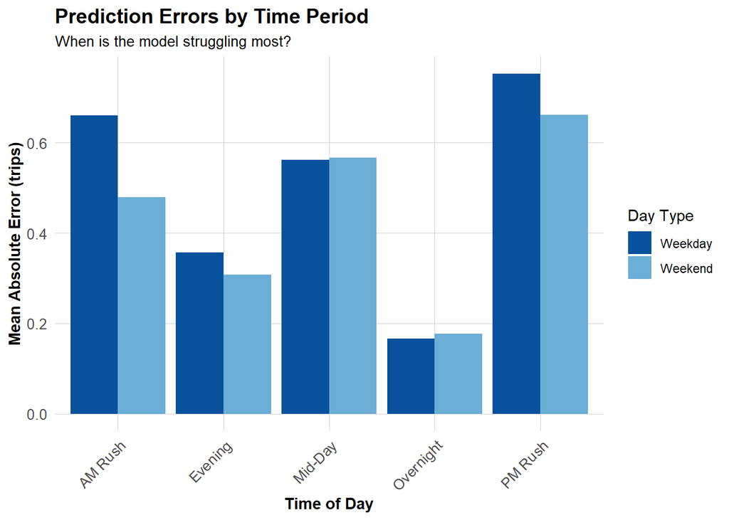

```r
# MAE by time of day and day type
temporal_errors <- test %>%
  group_by(time_of_day, weekend) %>%
  summarize(
    MAE = mean(abs_error, na.rm = TRUE),
    .groups = "drop"
  ) %>%
  mutate(day_type = ifelse(weekend == 1, "Weekend", "Weekday"))

ggplot(temporal_errors, aes(x = time_of_day, y = MAE, fill = day_type)) +
  geom_col(position = "dodge") +
  scale_fill_manual(values = c("Weekday" = "#08519c", "Weekend" = "#6baed6")) +
  labs(
    title = "Prediction Errors by Time Period",
    subtitle = "When is the model struggling most?",
    x = "Time of Day",
    y = "Mean Absolute Error (trips)",
    fill = "Day Type"
  ) +
  plotTheme +
  theme(axis.text.x = element_text(angle = 45, hjust = 1))
```

### Temporal Error Patterns

Prediction errors vary systematically across time periods. Errors are highest during peak commuting hours, particularly during morning and evening rush periods, when demand is both high and more volatile.

In contrast, overnight and low-demand periods exhibit lower errors, as usage is minimal and more stable.

There are also differences between weekdays and weekends, reflecting distinct travel behaviors. These patterns indicate that the model struggles most during high-demand periods, which are also the most important for operational decision-making.

## Errors and Demographics

Are prediction errors related to neighborhood characteristics?

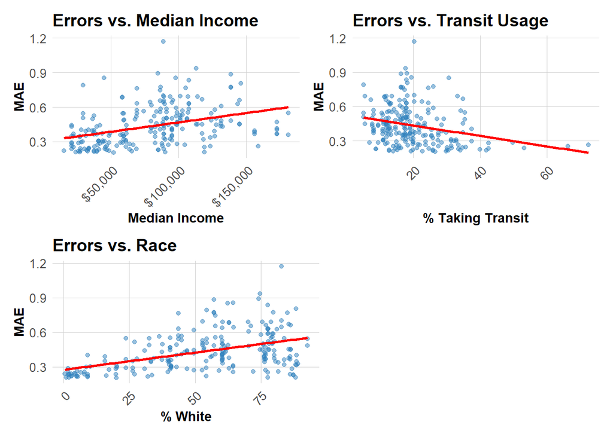

```r
# Join demographic data to station errors
station_errors_demo <- station_errors %>%
  left_join(
    station_attributes %>% select(start_station, Med_Inc, Percent_Taking_Transit, Percent_White),
    by = "start_station"
  ) %>%
  filter(!is.na(Med_Inc))

# Create plots
p1 <- ggplot(station_errors_demo, aes(x = Med_Inc, y = MAE)) +
  geom_point(alpha = 0.5, color = "#3182bd") +
  geom_smooth(method = "lm", se = FALSE, color = "red") +
  scale_x_continuous(labels = scales::dollar) +
  labs(title = "Errors vs. Median Income", x = "Median Income", y = "MAE") +
  plotTheme

p2 <- ggplot(station_errors_demo, aes(x = Percent_Taking_Transit, y = MAE)) +
  geom_point(alpha = 0.5, color = "#3182bd") +
  geom_smooth(method = "lm", se = FALSE, color = "red") +
  labs(title = "Errors vs. Transit Usage", x = "% Taking Transit", y = "MAE") +
  plotTheme

p3 <- ggplot(station_errors_demo, aes(x = Percent_White, y = MAE)) +
  geom_point(alpha = 0.5, color = "#3182bd") +
  geom_smooth(method = "lm", se = FALSE, color = "red") +
  labs(title = "Errors vs. Race", x = "% White", y = "MAE") +
  plotTheme

(p1 | p2) / (p3 | plot_spacer())
```

### Demographic Error Patterns and Equity Implications

This raises potential equity concerns. If prediction errors are systematically higher in certain neighborhoods, it could lead to unequal service quality, with some areas experiencing more frequent bike shortages or surpluses.

From a policy perspective, deploying such a model without adjustments could reinforce existing disparities in access to shared mobility. Safeguards such as minimum service thresholds or targeted rebalancing strategies may be necessary to ensure equitable outcomes.

## Critical Reflection

From an operational perspective, the final model achieves a relatively low MAE, suggesting it could be useful for informing bike rebalancing strategies. However, prediction errors during peak demand periods remain a concern, as these are the times when accurate forecasts are most critical. Even small errors during rush hours could lead to significant service disruptions.

From an equity standpoint, the presence of higher errors in certain neighborhoods raises concerns about uneven service provision. If the model is used to guide resource allocation, it could inadvertently disadvantage areas where predictions are less accurate. Ensuring equitable outcomes would require incorporating fairness considerations, such as prioritizing service reliability in underserved communities.

Finally, the model has several limitations. It does not account for special events, infrastructure differences, or behavioral factors that influence demand. Future improvements could include richer spatial data, event indicators, and more advanced modeling techniques to better capture these dynamics.

### Model Limitations and Future Improvements

While the model performs well overall, it misses several important patterns. Most notably, it does not account for short-term demand shocks such as special events, holidays, or disruptions (e.g., concerts, sports games, or transit outages), which can significantly influence bike usage. It also does not capture differences in infrastructure, such as bike lane availability or station capacity, which may affect demand across locations.

The model also relies on several assumptions that may not hold in real-world deployment. It assumes that relationships between predictors and demand remain stable over time, but in practice, travel behavior can shift due to seasonal changes, policy interventions, or broader mobility trends. Additionally, the model assumes that past demand is always a reliable predictor of future demand, which may break down during unusual conditions such as extreme weather or sudden demand spikes.

With more time and data, the model could be improved in several ways. Incorporating event data, holiday indicators, and land-use or points-of-interest data would help capture spatial and temporal variability more accurately. More advanced modeling approaches, such as machine learning models or hierarchical models, could better account for non-linear relationships and station-level heterogeneity. Finally, integrating real-time data streams could improve responsiveness and make the model more useful for operational decision-making.